# Primo blocco di esercizi TAD 2018/19

## 3. Numeri generati da una log-Normale

Premessa:

Il costo medio medio sinitri è di 4500 euro.

I momenti della log-normale sono: $\begin{aligned}\operatorname {E} [X]&= e^{\mu +{\tfrac {1}{2}}\sigma ^{2}} (\overset{\triangle}{=}4500) \\ \operatorname {Var} [X]&= e^{2\mu +\sigma ^{2}}(e^{\sigma ^{2}}-1){\overset{\triangle}{=}30000} \end{aligned}$

da cui ricavo che

${\begin{aligned}\mu &=\ln \left({\frac {\operatorname {E} [X]^{2}}{\sqrt {\operatorname {E} [X^{2}]}}}\right)=\ln \left({\frac {\operatorname {E} [X]^{2}}{\sqrt {\operatorname {Var} [X]+\operatorname {E} [X]^{2}}}}\right),\\[4pt]\sigma ^{2}&=\ln \left({\frac {\operatorname {E} [X^{2}]}{\operatorname {E} [X]^{2}}}\right)=\ln \left(1+{\frac {\operatorname {Var} [X]}{\operatorname {E} [X]^{2}}}\right).\end{aligned}}$

### Simulato con algoritmi di r

### 1000 determinazioni simulate

```r
## Generazione dati
det1=exp(rnorm(1000, mean=0, sd=1))
## Si potrebbe usare direttamente il comando rlnorm

##Indici sintetici
mean(det1)
```

```
## [1] 1.644088
```

```r
var(det1)
```

```
## [1] 4.980726
```

```r
#I valori teorici sono rispettivamente
exp(0+1/2)
```

```
## [1] 1.648721
```

```r
exp(1)*(exp(1)-1)
```

```
## [1] 4.670774
```

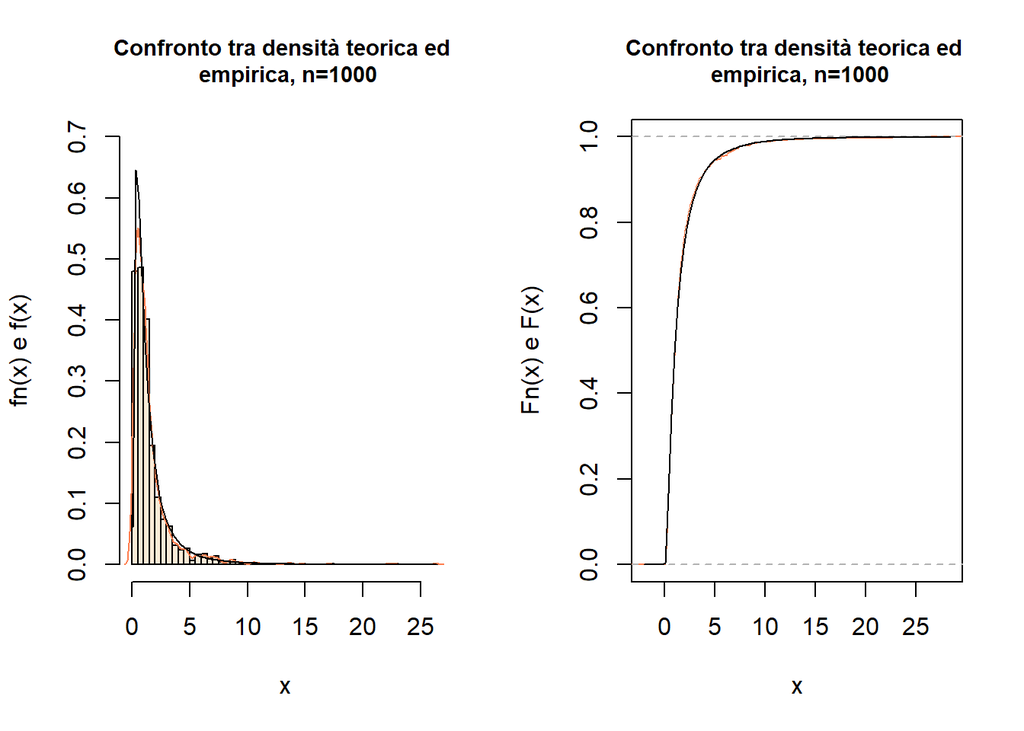

```r
par(mfrow=c(1,2))
## Funzione di densità
hist(det1, freq=FALSE,ylim=c(0,0.7), breaks=50, col="antiquewhite", xlab="x",
     ylab="fn(x) e f(x)", main = "Confronto tra densità teorica ed \n empirica, n=1000", cex.main=0.9)
points(density(det1), xlim=c(min(det1), max(det1)), col="coral", type="l")
curve(dlnorm, xlim=c(min(det1), max(det1)), col="black", pch=20, add=TRUE)

## Funzione di ripartizione
plot(ecdf(det1), col="coral", main="Confronto tra densità teorica ed \n empirica, n=1000", ylab="Fn(x) e F(x)", xlab="x", cex.main=0.9)
curve(plnorm, col="black", add=TRUE)
```

### 10000 determinazioni simulate

```r
## Generazione dati
det2=exp(rnorm(10000, mean=0, sd=1))

## Indici sintetici
mean(det2)
```

```
## [1] 1.688526
```

```r
var(det2)
```

```
## [1] 4.964538
```

```r
## Media e varianza empirica
exp(0+1/2)
```

```
## [1] 1.648721
```

```r
exp(1)*(exp(1)-1)
```

```
## [1] 4.670774
```

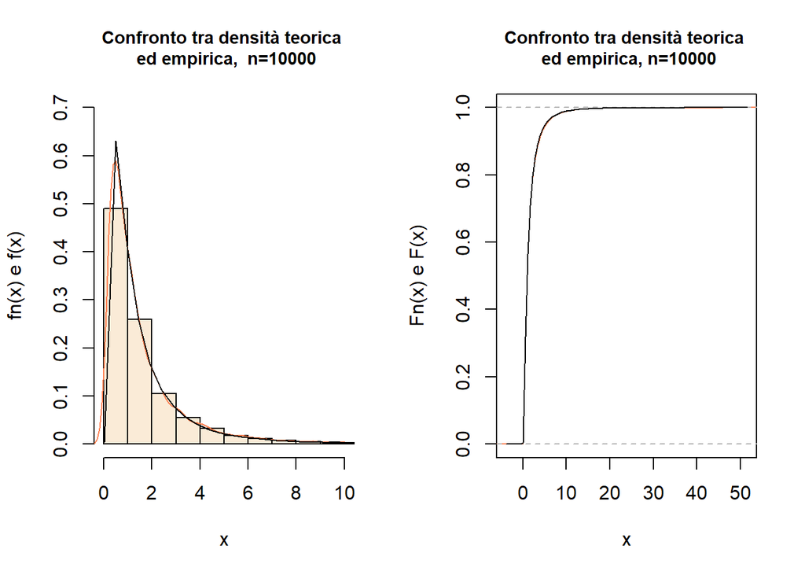

```r
par(mfrow=c(1,2))
## Funzione di densità
hist(det2, freq=FALSE,ylim=c(0,0.7), xlim=c(0,10), breaks=50, col="antiquewhite", xlab="x", ylab="fn(x) e f(x)", main = "Confronto tra densità teorica \n ed empirica,  n=10000", cex.main=0.9)
points(density(det2), xlim=c(min(det2), max(det2)), col="coral", type="l")
curve(dlnorm, xlim=c(min(det2), max(det2)), col="black", pch=20, add=TRUE)

## Funzione di ripartizione
plot(ecdf(det2), col="coral", main="Confronto tra densità teorica \n ed empirica, n=10000", ylab="Fn(x) e F(x)", xlab="x", cex.main=0.9)
curve(plnorm, col="black", add=TRUE)
```

### Confronto tra det1 e det2

```r
mean(det1)
```

```
## [1] 1.644088
```

```r
mean(det2)
```

```
## [1] 1.688526
```

```r
var(det1)
```

```
## [1] 4.980726
```

```r
var(det2)
```

```
## [1] 4.964538
```

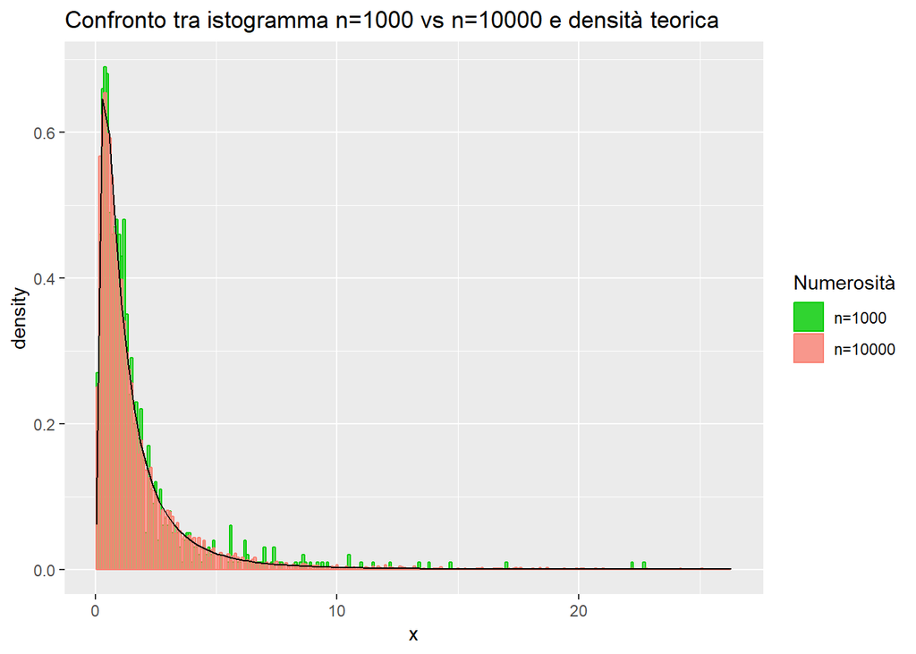

```r
data1 <- data.frame(det1)
data2 <- data.frame(det2)
ggplot(data.frame(x=c(-5,5)),aes(x)) +
  geom_histogram(aes(x=det1, y=..density.., fill="g", colour="g"), alpha=0.5, data=data1, binwidth = 0.1) +
  geom_histogram(aes(x=det2,y=..density.., fill="s", colour="s"), alpha=0.6, data=data2, binwidth = 0.1) +
  scale_colour_manual(name="Numerosità", values=c("g" = "green3", "s"="salmon"),
                      labels=c("s"="n=10000", "g"="n=1000")) +
  scale_fill_manual(name="Numerosità", values=c("g" = "green3", "s"="salmon"),
                    labels=c("s"="n=10000", "g"="n=1000")) +
  xlim(c(min(det1),max(det1))) +
  stat_function(fun = dlnorm, color = "black")+
ggtitle("Confronto tra istogramma n=1000 vs n=10000 e densità teorica")
```

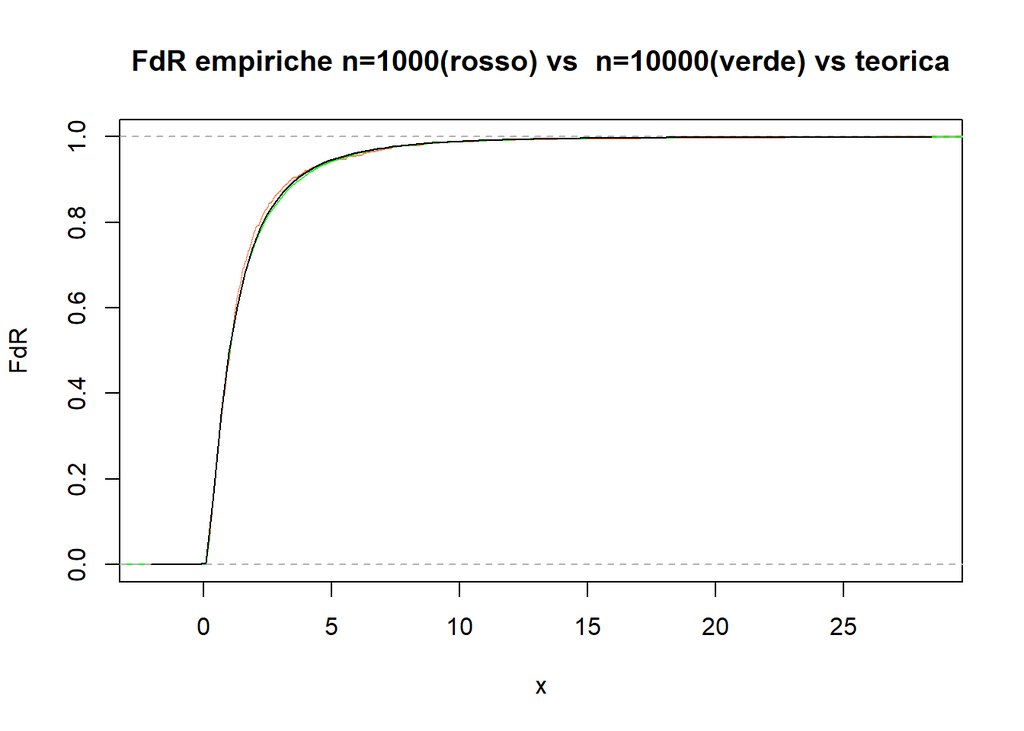

```r
par(mfrow=c(1,1))
plot(ecdf(det1), col="coral", main="FdR empiriche n=1000(rosso) vs  n=10000(verde) vs teorica", xlab="x", ylab="FdR")
plot(ecdf(det2), col="green", add=T)
curve(plnorm, col="black", add=TRUE)
```

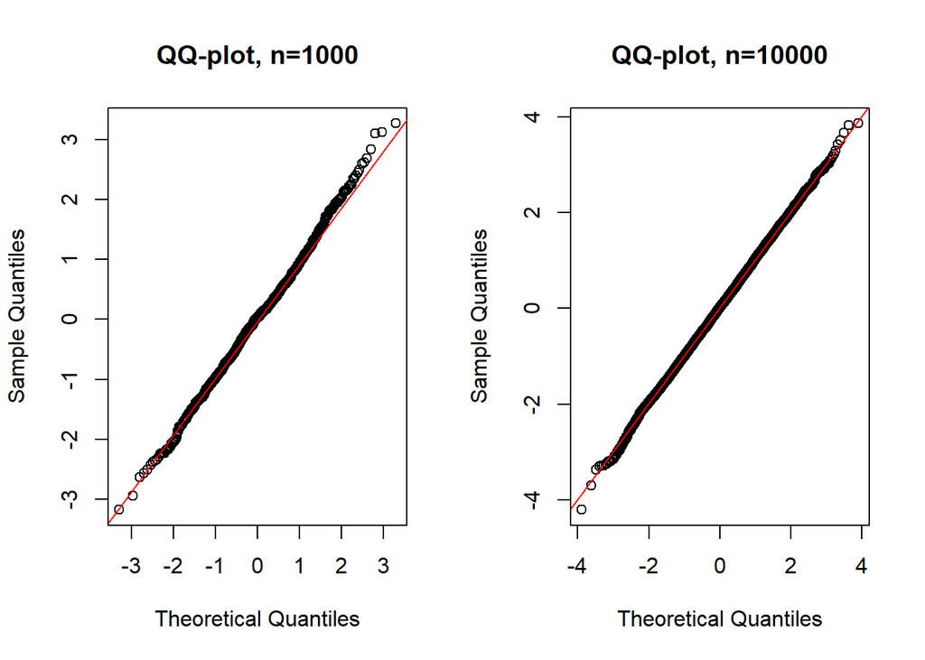

```r
# QQ-plot (log-norm)
par(mfrow =c(1,2))

qqnorm(log(det1), main="QQ-plot, n=1000")
qqline(log(det1), col= "red")

qqnorm(log(det2), main="QQ-plot, n=10000")
qqline(log(det2), col= "red")
```

## 4. Numeri generati da una esponenziale (gamma)

Può essere usata per calcolare il numero atteso di sinistri.

### 1000 determinazioni simulate

```r
## Ipotiziamo un parametro pari a 1
det1=-log(runif(1000, 0, 1))
## Si potrebbe usare direttamente il comando rexp.

##Indici sintetici
mean(det1)
```

```
## [1] 1.020005
```

```r
var(det1)
```

```
## [1] 1.020261
```

```r
## media teorica: 1 e varianza teorica: 1
```

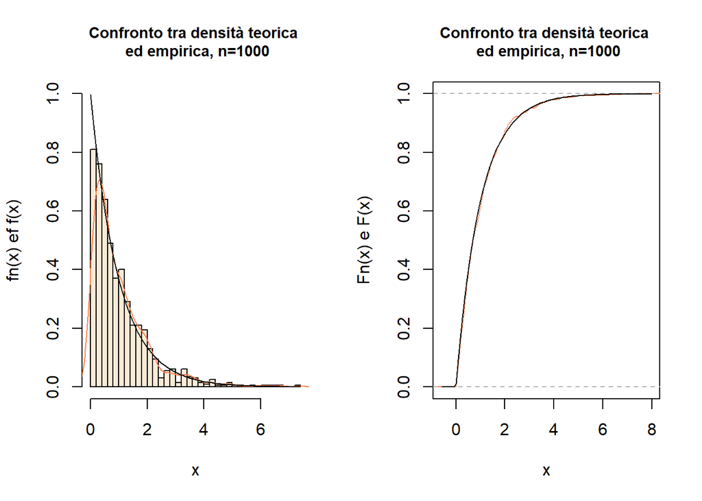

```r
par(mfrow=c(1,2))
## Funzione di densità
hist(det1, freq = FALSE, ylim=c(0,1), breaks= 30,col="antiquewhite", xlab="x",
     ylab="fn(x) ef f(x)", main = "Confronto tra densità teorica \n ed empirica, n=1000", cex.main=0.9)
points(density(det1), xlim=c(min(det1), max(det1)), col="coral", type="l")
curve(dexp, xlim=c(min(det1), max(det1)), col="black", pch=20, add=TRUE)

## Funzione di ripartizione
plot(ecdf(det1), col="coral", main="Confronto tra densità teorica \n ed empirica, n=1000", cex.main=0.9, ylab="Fn(x) e F(x)", xlab="x")
curve(pexp, col="black", add=TRUE)
```

### 10000 determinazioni simulate

```r
# Generazione dati
det2=-log(runif(10000, 0, 1))

#Indici sintetici
mean(det2)
```

```
## [1] 0.98181
```

```r
var(det2)
```

```
## [1] 0.9741783
```

```r
# media teorica: 1 e varianza teorica: 1
```

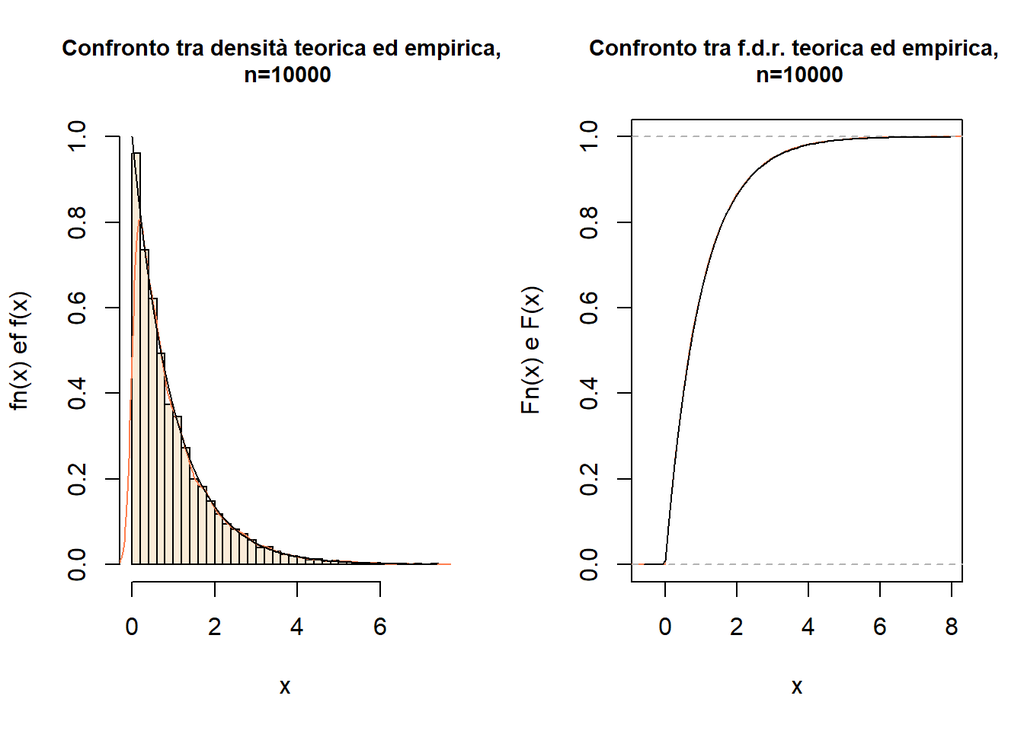

```r
par(mfrow=c(1,2))
## Funzione di densità
hist(det2, freq = FALSE, ylim=c(0,1), breaks=50, col="antiquewhite", xlab="x", ylab="fn(x) ef f(x)", main = "Confronto tra densità teorica ed empirica, \n n=10000", cex.main=0.9)
points(density(det2), xlim=c(min(det2), max(det2)), col="coral", type="l")
curve(dexp, xlim=c(min(det2), max(det2)), col="black", pch=20, add=TRUE)

## Funzione di ripartizione
plot(ecdf(det2), col="coral", main="Confronto tra f.d.r. teorica ed empirica, \n n=10000", ylab="Fn(x) e F(x)", xlab="x", cex.main=0.9)
curve(pexp, col="black", add=TRUE)
```

### Confronto tra det1 e det2

```r
mean(det1)
```

```
## [1] 1.020005
```

```r
mean(det2)
```

```
## [1] 0.98181
```

```r
var(det1)
```

```
## [1] 1.020261
```

```r
var(det2)
```

```
## [1] 0.9741783
```

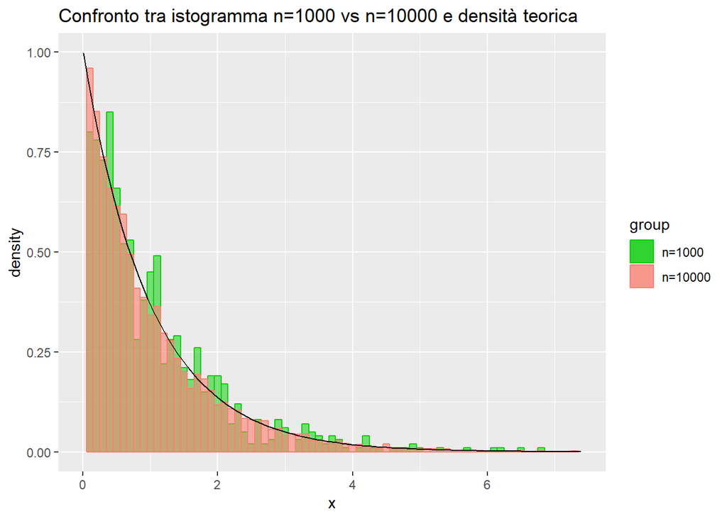

```r
data1 <- data.frame(det1)
data2 <- data.frame(det2)
ggplot(data.frame(x=c(-5,5)),aes(x)) +
  geom_histogram(aes(x=det1, y=..density.., fill="g", colour="g"), alpha=0.5, data=data1,binwidth = 0.1) +
  geom_histogram(aes(x=det2,y=..density.., fill="s", colour="s"), alpha=0.6, data=data2, binwidth = 0.1) +
  scale_colour_manual(name="group", values=c("g" = "green3", "s"="salmon"),
                      labels=c("s"="n=10000", "g"="n=1000")) +
  scale_fill_manual(name="group", values=c("g" = "green3", "s"="salmon"),
                    labels=c("s"="n=10000", "g"="n=1000")) +
  xlim(c(min(det1),max(det1))) +
  stat_function(fun = dexp, color = "black")+
ggtitle("Confronto tra istogramma n=1000 vs n=10000 e densità teorica")
```

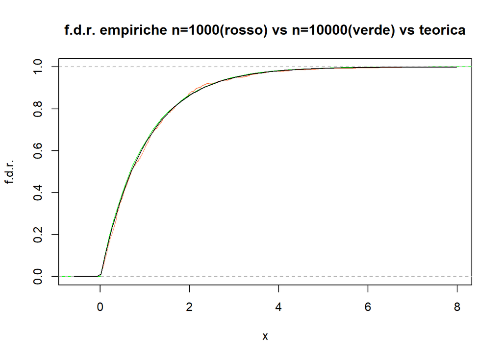

```r
par(mfrow=c(1,1))
plot(ecdf(det1), col="coral", main="f.d.r. empiriche n=1000(rosso) vs n=10000(verde) vs teorica", xlab="x", ylab="f.d.r.")
plot(ecdf(det2), col="green", add=T)
curve(pexp, col="black", add=TRUE)
```

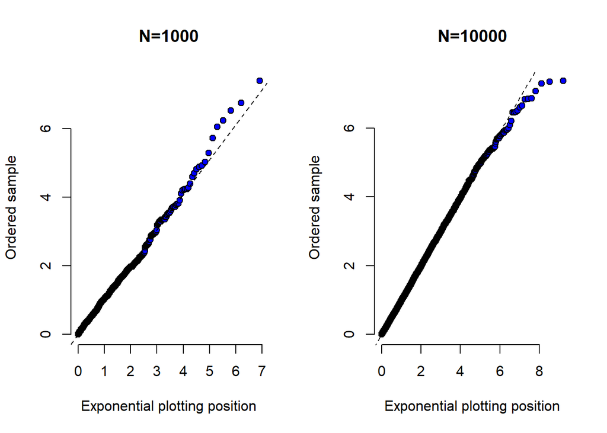

```r
par(mfrow =c(1,2))
qqexp(det1,pch=21,bg="blue",bty="n", line=TRUE, main="N=1000")
qqexp(det2,pch=21,bg="blue",bty="n", line=TRUE, main="N=10000")
```

### 1000 Determinazioni simulate

```r
det1=rgamma(1000, 4.7,5.9)
alfa= 4.7
beta=5.9

##Inidici sintetici
mean(det1)
```

```
## [1] 0.8187136
```

```r
var(det1)
```

```
## [1] 0.1429837
```

```r
## Media e varianza teorica:
alfa/beta
```

```
## [1] 0.7966102
```

```r
alfa/beta^2
```

```
## [1] 0.1350187
```

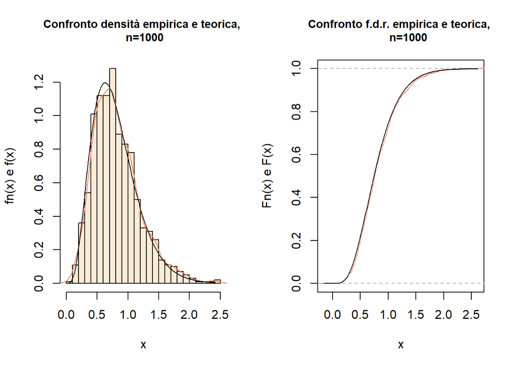

```r
par(mfrow=c(1,2))
## Funzione di densità
hist(det1, freq=FALSE, breaks=30,col="antiquewhite",
main="Confronto densità empirica e teorica, \n n=1000", xlab="x", ylab="fn(x) e f(x)",
cex.main=0.9)
points(density(det1), xlim=c(min(det1), max(det1)), col="coral", type="l")
curve(dgamma(x,4.7,5.9),  xlim=c(min(det1), max(det1)), col="black", pch=20, add=TRUE)

#Funzione di ripartizione
plot(ecdf(det1), col="coral2", main="Confronto f.d.r. empirica e teorica,
     n=1000",xlab="x", ylab="Fn(x) e F(x)", cex.main=0.9)
curve(pgamma(x,alfa,beta), col="black", add=TRUE)
```

### 10000 Determinazioni simulate

```r
det2=rgamma(10000, 4.7,5.9)
alfa= 4.7
beta=5.9

## Indici sintetici
mean(det2)
```

```
## [1] 0.7943623
```

```r
var(det2)
```

```
## [1] 0.1305188
```

```r
## Media e varianza teorica:
alfa/beta
```

```
## [1] 0.7966102
```

```r
alfa/beta^2
```

```
## [1] 0.1350187
```

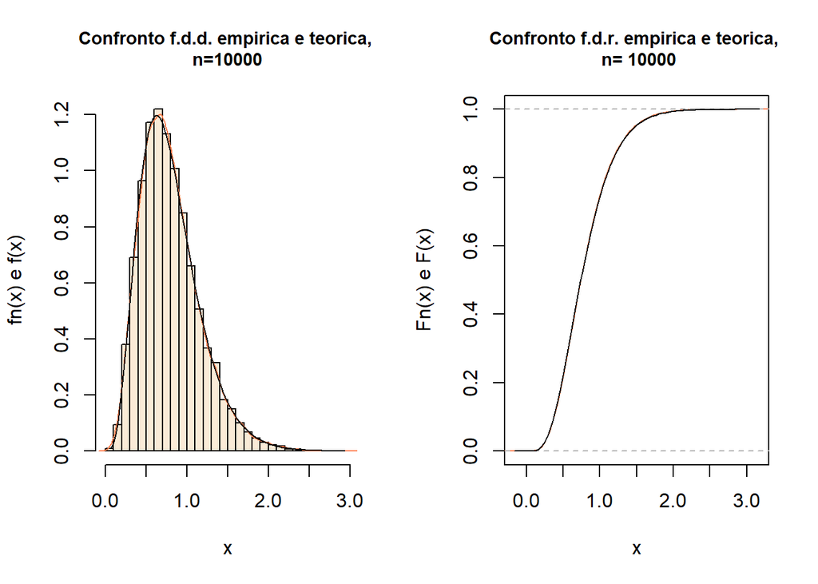

```r
par(mfrow=c(1,2))
# Funzione di densità
hist(det2, freq=FALSE,breaks=40, col="antiquewhite",
main="Confronto f.d.d. empirica e teorica, \nn=10000", xlab="x", ylab="fn(x) e f(x)",
cex.main=0.9)
points(density(det2), xlim=c(min(det2), max(det2)), col="coral", type="l")
curve(dgamma(x,4.7,5.9),  xlim=c(min(det2), max(det2)), col="black", pch=20, add=TRUE)

#Funzione di ripartizione
plot(ecdf(det2), col="coral", main="Confronto f.d.r. empirica e teorica, \n n= 10000",
     xlab="x", ylab="Fn(x) e F(x)", cex.main=0.9)
curve(pgamma(x,alfa,beta), col="black", add=TRUE)
```